# Proceso estocástico

# Proceso de Wiener Generalizado

Sabemos que de Wiener Generalizado la ecuación es:

$$dX=adt+bdW$$

Donde
$$dW=\epsilon\sqrt{dt}$$

Entonces para poder simularlo necesitamos : $a$ y $b$

```r
a <- .8
b <- 5

dx <- a*dt+b*dw
```

¿Cómo es la variable X?

$$X=X_{t-1}+dX$$

Construimos la variable X

```r
X <- 10
X[1]<-X

for(t in 2:obs){
  X[t] <- X[t-1]+dx[t]
}
datos <- mutate(datos, X=X, dX=dx)

str(datos)
```

```
## tibble [5,000 x 5] (S3: tbl_df/tbl/data.frame)
##  $ t : num [1:5000] 0.0002 0.0004 0.0006 0.0008 0.001 0.0012 0.0014 0.0016 0.0018 0.002 ...
##  $ dw: num [1:5000] -0.01707 0.00392 0.01534 -0.03317 0.00607 ...
##  $ W : num [1:5000] 9 9 9.02 8.99 8.99 ...
##  $ X : num [1:5000] 10 10.02 10.1 9.93 9.96 ...
##  $ dX: num [1:5000] -0.0852 0.0198 0.0768 -0.1657 0.0305 ...
```

Graficamos la variable X

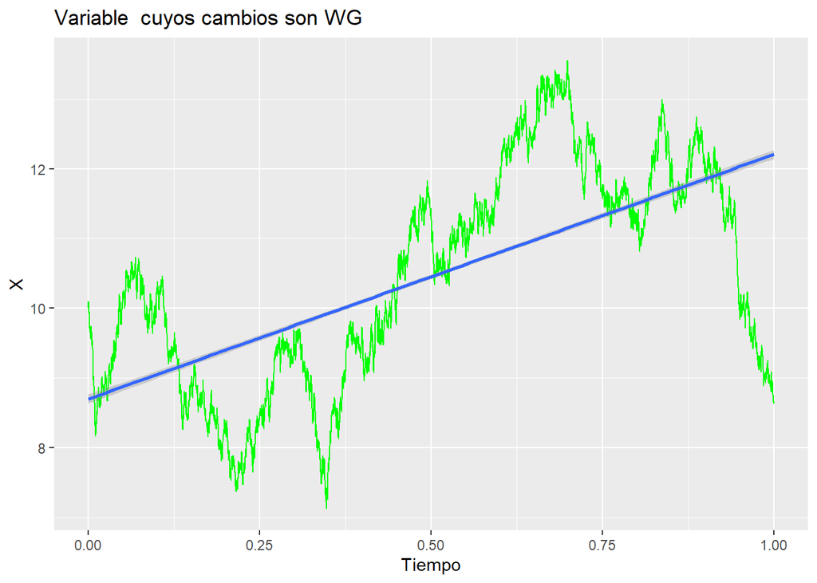

```r
ggplot(datos)+
  geom_line(aes(x=t, y=X), color="green")+
  labs(x="Tiempo", y="X", title = "Variable  cuyos cambios son WG") +
  geom_smooth(aes(x=t, y=X), method=lm)
```

# Problemas

Resolver el siguiente problema:

Procesos estocásticos: Problema de simulación Tenemos una variable que sigue un proceso de Wiener Generalizado con drift rate de 2 y una tasa de varianza de 4, por unidad de tiempo ambas semestrales. Nuestro objetivo es analizar el comportamiento de la variable dentro de 1 año, por lo cual tenemos los siguientes datos:

Sabemos que los cambio de $dX$ se comportan así:

$$dX=adt+bdW$$

Donde

$$dW=\epsilon\sqrt{dt}$$

- ¿Cuánto vale a? En un proceso de WG la tasa de flujo (drift rate), es una constante es $a=2$
- ¿Cuánto vale b? En un proceso de WG, la tasa de varianza también es una constante y es $b^2$, por lo tanto en caso si la tasa de varianza es 4, $b=2$.
- ¿Cuánto vale dt? En este caso $dt=2$, ya que los datos están expresados en términos semestrales y queremos analizar los cambios a un año; en un año hay $2$ semestres.
- ¿Cuál es la ecuación especifica de $dX$?

$$dX=4+2\sqrt{2}\epsilon$$

Simula el comportamiento de este cambio para dentro de un año. En este caso cada épsilon que simulemos será un posible escenario, usa 100,000 escenarios (observaciones de dx).

```r
rm(list=ls())
set.seed(123)

epsilon <- rnorm(100000, mean = 0, sd=1)

dX <- 4+2*sqrt(2)*epsilon

str(dX)
```

```
##  num [1:100000] 2.41 3.35 8.41 4.2 4.37 ...
```

1. ¿Cómo se distribuye dx?

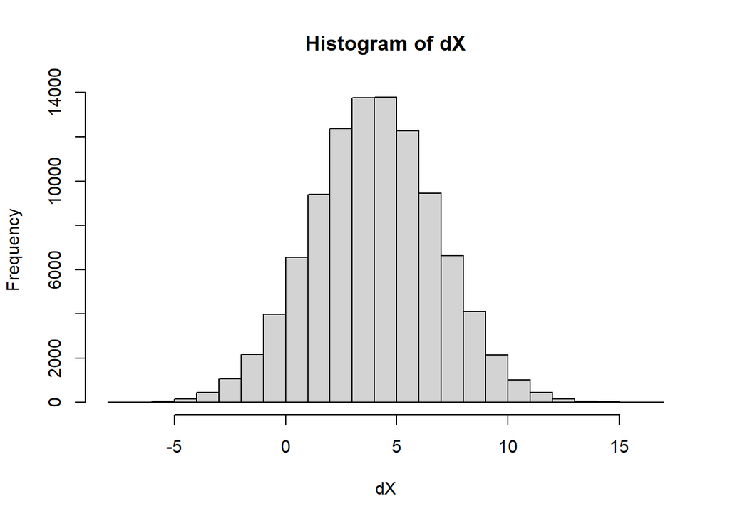

```r
hist(dX)
```

2. ¿Cuál sería el valor esperado en la variable para dentro de un año? ¿Y su varianza y su desviación estándar? (empíricos)

```r
mean(dX)
```

```
## [1] 4.002763
```

```r
var(dX)
```

```
## [1] 7.995735
```

```r
sd(dX)
```

```
## [1] 2.827673
```

3. ¿Cómo se distribuye dx teóricamente?

Del proceso de Wiener generalizado sabemos:

$$E[dX]=adt=4$$
$$Var[dX]=b^2dt=8$$

$$\sigma=b\sqrt{dt}=2*\sqrt{2}$$

Entonces sabemos que

$$X \approx N(4,8)$$

4. Suponemos que su valor inicial de la variable es 50. ¿Cuál es el valor esperado de la variable para el próximo año?

Construimos $X$, sabemos que:

$$X=X_0+dX$$

De forma especifica:

$$X=50+4+2\sqrt{2}\epsilon=54+2\sqrt{2}\epsilon$$

```r
X <- 54+2*sqrt(2)*epsilon
```

Valor esperado (media)

```r
mean(X)
```

```
## [1] 54.00276
```

5. ¿Cómo se distribuye X?

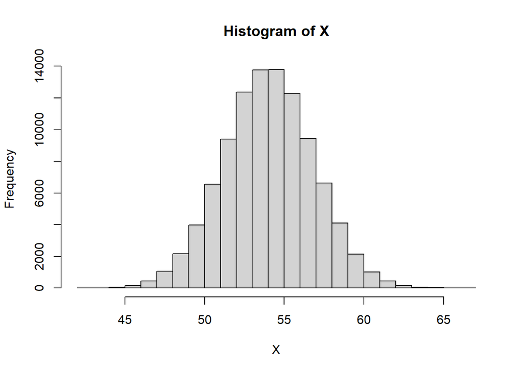

```r
hist(X)
```

6. ¿Cuál es la probabilidad de que el cambio dX en un año sea mayor a cero?

```r
mean(dX>0)
```

```
## [1] 0.92139
```

7. ¿Cuál es la probabilidad de que X, sea mayor a 50?

```r
mean(X>50)
```

```
## [1] 0.92139
```

8. ¿Cuál sería la probabilidad de que la variable X, se encuentre entre 57 y 65?

```r
mean(X<=65)-mean(X<=57)
```

```
## [1] 0.14519
```